# Bayesian Statistics: A practical introduction

Lab 1

Richard D. Morey, Cardiff University (richarddmorey@gmail.com)

Each example contains R code for you to run by cutting and pasting the code from the document into R. The output should look similar to the output in the document below.

Before you start, you should change your R working directory to whatever directory you have stored the lab files in. This can be done through the `File...` menu in Windows, or in all platforms using the `setwd()` function.

## Regression

### Fully-worked example

This example was taken from Jackman’s “Bayesian Analysis for the Social Sciences”, section 6.3. Most of the code is by Simon Jackman.

> In Nov. 1993, Pennsylvania held legislative election. In the 2nd district, the Democratic candidate lost to the Republican candidate by a count of the machine-cast votes, 19,127 to 19,691. Among hand-counted absentee ballots, the Democrat won 1,396 to 371. The Republican sued, saying the absentee count was fraudulent. See the plot below to see the anomolous district (in red).

We first load Jackman’s pscl library, which contains the data. If the `library()` command fails, uncomment the `install.packages()` line by removing the # symbol and run it first.

```r
# install.packages('pscl')
library(nimble)
library(mcmc)
library(pscl)
data(absentee)
attach(absentee)
```

`attach()` makes it so that we can refer to the columns of the `absentee` data frame without explicitly saying `absentee` every time.

The next two lines of code create the data that we will be dealing with; the percent advantage, in favor of the Democrats, for both absentee (abs) and machine counted (mach) ballots.

```r
y <- (absdem - absrep)/(absdem + absrep)*100
x <- (machdem - machrep)/(machdem + machrep)*100
```

The machine-counted vote percentage will be our predictor, and will predict the absentee ballot vote.

We can plot the data in R:

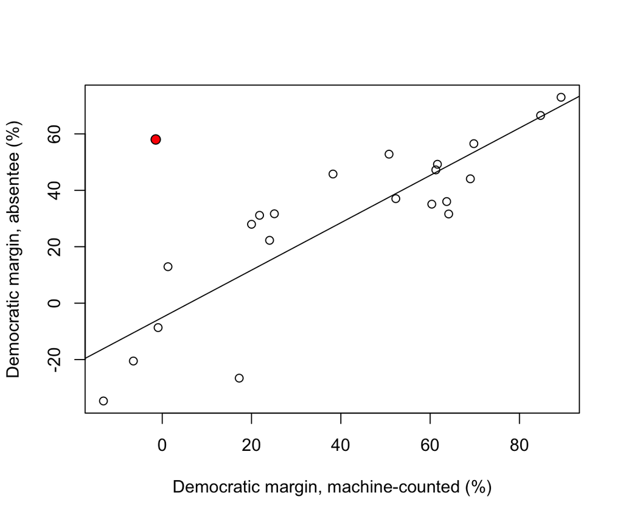

```r
plot(y~x, xlab = "Democratic margin, machine-counted (%)",
     ylab="Democratic margin, absentee (%)")
points(x[22],y[22],pch=21,bg="red",cex=1.2)

# plot least squares line while eliminating
# the 22, anomolous, point
abline(lm(y[1:21]~x[1:21]))
```

We need to create a list, which in R is a sort of ‘grouping’ of variables, that we will pass to Nimble. It must contain all the necessary information for the analysis.

```r
## environment for passing to Nimble
forNimble <- list(y=y[1:21],
                N = 21,
                x=x[1:21],
                xstar=x[22])
```

For each member of the list, the left-hand side is the name as Nimble will see it, and the right-hand side is what we are calling the data in R. Notice that we are eliminating the 22nd data point, which is the strange one. We pass the strange $x$ value as `xstar`.

We now create another list, containing settings for Nimble. Almost all of the time (including here) this is unncessary, because Nimble will guess the starting values and use good default settings; this is for demonstration.

```r
## initial values in a list
inits <- list(beta=c(0,0),
                   sigma=5,
                   ystar=0)
```

We now ‘compile’ the model by telling Nimble to combine the data (in `forNimble`), the setup (in `inits`), and the model definition (in the file `regression.bug`).

```r
nimble.model <- nimble::readBUGSmodel(
  model="regression.bug",
  data=forNimble,
  inits=inits)
```

```
## Defining model
```

```
##   [Note] Using 'y' (given within 'constants') as data.
```

```
## Building model
```

```
## Setting data and initial values
```

```
## Running calculate on model
##   [Note] Any error reports that follow may simply reflect missing values in model variables.
```

```
## Checking model sizes and dimensions
```

```r
compiled.model = compileNimble(nimble.model)
```

```
## Compiling
##   [Note] This may take a minute.
##   [Note] Use 'showCompilerOutput = TRUE' to see C++ compilation details.
```

```r
conf <- configureMCMC(nimble.model)
conf$addMonitors(c("beta", "sigma", "ystar"))

# Build the MCMC
Rmcmc <- buildMCMC(conf)
Cmcmc <- compileNimble(Rmcmc, project = compiled.model)
```

```
## Compiling
##   [Note] This may take a minute.
##   [Note] Use 'showCompilerOutput = TRUE' to see C++ compilation details.
```

The contents of regression.bug is simply text describing the model. (Do not run this code in R; it is BUGS code, not R code.)

```
model{
    for(i in 1:N){   ## regression model for y
          mu[i] <- beta[1] + beta[2]*x[i]
          y[i] ~ dnorm(mu[i],tau)
    }
    ## priors
    beta[1] ~ dnorm(0,.0001)   ## intercept
    beta[2] ~ dnorm(0,.0001)   ## slope
    sigma ~ dunif(0,100)       ## residual std dev
    tau <- pow(sigma,-2)       ## convert to precision

    ## out of sample predicton for suspect case
    mustar <- beta[1] + beta[2]*xstar
    ## posterior predictive density for y[22] given
    ## historical data obs 1 - 21 and x[22]
    ystar ~ dnorm(mustar,tau)
}
```

Lines after line 11 are the code for the out-of-sample prediction. `mustar` is the predicted value for the anomolous point based on the mahine counted votes; `ystar` is a sample from its posterior predictive distribution - where we would predict the absentee ballot count to be, accounting for the uncertainty in all variables.

Having compiled the Nimble model, we can now sample from the joint posterior distribution. `Cmcmc` is what we called our compiled model. `conf$addMonitors()` above tells Nimble which variables we are interested in. Nimble will only report back values of these variables. `niter` is the number of Gibbs sampler iterations to run.

```r
samples <- runMCMC(Cmcmc, niter = 50000)
```

```
## running chain 1...
```

The more iterations, the better the results, but the longer it takes. The variable `samples` now contains our analysis.

We can get summaries of the variables:

```r
samples |>
  coda::as.mcmc() |>
  summary()
```

```
##
## Iterations = 1:50000
## Thinning interval = 1
## Number of chains = 1
## Sample size per chain = 50000
##
## 1. Empirical mean and standard deviation for each variable,
##    plus standard error of the mean:
##
##            Mean      SD  Naive SE Time-series SE
## beta[1] -4.9794  5.9508 0.0266128       0.059455
## beta[2]  0.8377  0.1177 0.0005266       0.001153
## sigma   15.9224  2.8286 0.0126499       0.032837
## ystar   -6.2399 17.2556 0.0771693       0.102269
##
## 2. Quantiles for each variable:
##
##             2.5%      25%     50%    75%  97.5%
## beta[1] -16.6948  -8.8424 -4.9861 -1.124  6.815
## beta[2]   0.6029   0.7607  0.8381  0.914  1.071
## sigma    11.5335  13.9283 15.5743 17.514 22.551
## ystar   -40.4451 -17.4390 -6.1801  4.956 27.549
```

We can compare these values to the classical estimates:

```r
linreg <- lm(y[1:21] ~ x[1:21])
summary(linreg)
```

```
##
## Call:
## lm(formula = y[1:21] ~ x[1:21])
##
## Residuals:
##     Min      1Q  Median      3Q     Max
## -35.973 -10.002   0.873  15.242  18.747
##
## Coefficients:
##             Estimate Std. Error t value Pr(>|t|)
## (Intercept)  -5.0849     5.4524  -0.933    0.363
## x[1:21]       0.8395     0.1080   7.774 2.56e-07 ***
## ---
## Signif. codes:  0 '***' 0.001 '**' 0.01 '*' 0.05 '.' 0.1 ' ' 1
##
## Residual standard error: 14.8 on 19 degrees of freedom
## Multiple R-squared:  0.7608, Adjusted R-squared:  0.7482
## F-statistic: 60.43 on 1 and 19 DF,  p-value: 2.559e-07
```

The first element in `samples` is a data frame containing all of our samples. We can plot the MCMC chains:

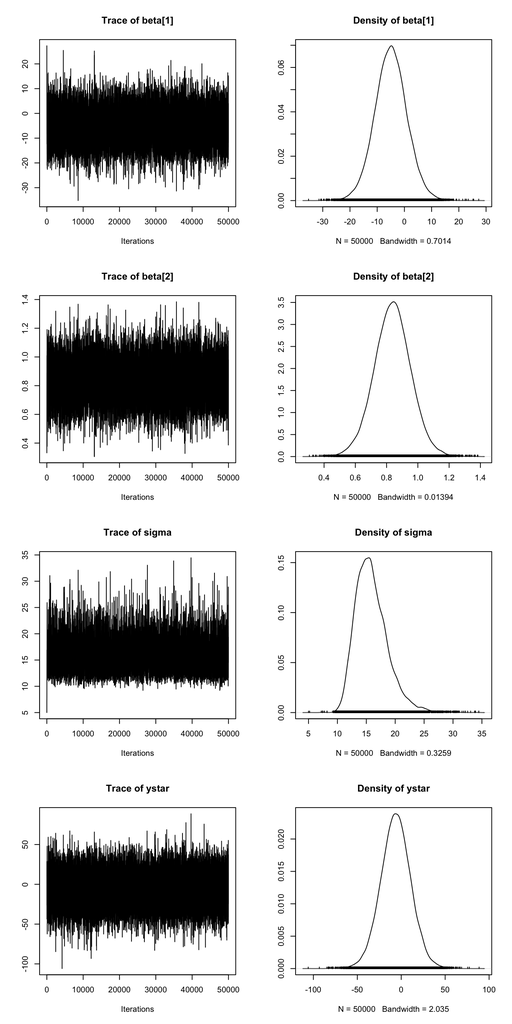

```r
samples |>
  coda::as.mcmc() |>
  plot()
```

We are particularly interested in the posterior predictive distribution for y[22], which is contained in column 4 of the MCMC output in `samples`. We can plot this separately:

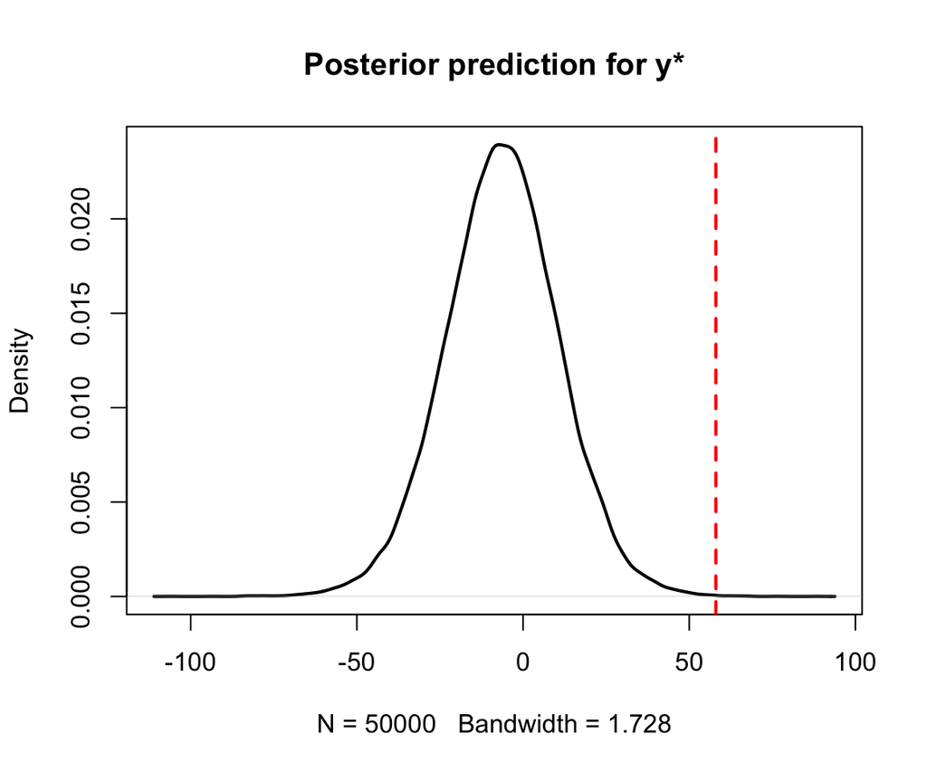

```r
ystar = samples[,4]
# plot kernel density estimate
plot(density(ystar), lwd=2, main = "Posterior prediction for y*")
# add vertical line
abline(v = y[22], col="red", lty=2, lwd=2)
```

The red vertical line is the observed value. As can be clearly seen, the value is quite outside the range we would expect on the basis of the other points.

We can also estimate the posterior predictive probability that y[22] would be greater than the observed value.

```r
mean(ystar>y[22])
```

```
## [1] 0.00038
```

There appears to be evidence that the district in question is anomolous.

### Extending the example: missing data

In this exercise, we will accomplish the same thing as above, except from a different perspective: eliminating `y[22]` and treating it as missing. To do this, you’ll need to modifying the BUGS file and change the R code. The easiest way to change the R code is to copy it all into an R script window for editing.

Steps:

1. Copy the file `regression.bug` to a new file, `regression2.bug`.
2. Edit the code in `regression2.bug` to remove all code having to do with the out-of-sample prediction (after line 11). Make sure you don’t accidentally remove the last `}`.
3. After the lines defining `x` and `y` in the R code, add the following lines of R code: `y2 <- y` and `y2[22] <- NA`. What we’re doing is making `y2[22]` into missing data.
4. Remove all references to `ystar` and `xstar` in the code you ran above.
5. In `forNimble`, correct `x=x[1:21]` to `x=x` (because we’re going to use all 22 values in `x`) and `y=y[1:21]` to `y=y2`.
6. Remove `ystar` from the `conf$addMonitors()`, and add `y[22]`.
7. Change your code to refer to `regression2.bug` instead of `regression.bug`.
8. Run all the (newly edited) code, up to and including plotting the posterior densities in `samples`.

What will happen is that Nimble will see that `y[22]` is missing, and will sample from its posterior distribution! In this way, the Bayesian model correctly accounts for incertainty given the missing data. Plot the posterior of `y[22]`. Do you get the same result as we did previously (you should).

### Modifying the model: adding a quadratic term

1. Copy the file `regression2.bug` to a new file, `regression3.bug`.
2. Add a quadratic term to the model in `regression3.bug` (still excluding `y[22]`), modifying the BUGS and R code so that you can estimate the parameters. The new coefficient for the quadratic term should be `beta[3]`.
3. Perform the traditional analysis with the `lm()` function (see above) adding a quadratic term. Compare the classical regression result with the Bayesian posterior.
4. What do you conclude about the anomolous `y[22]`? Is it still anomolous? Why or why not?